# Machine Learning Project

Kudakwashe Mhandire

29/04/2020

## Overview

This project aims to predict and classify how dumbell curls (outcome variable is called classe) were carried out using data from accelerators fitted to each of the 6 study participants’ belt, forearm, arm and dumbell. Each participant performed 10 repitition of the curls according to methods A-E as described by Ugulino et., 2012. This analysis involves 2 methods of classification, decision tree and random forest which were fitted on 70% pml_training data set and validated on the remaining 30%. The more accurate of the 2 methods will be used to predict the classes of 20 observations in a separate pml_testing data set.

## Load and explore the data sets.

```r
#Load training data
library(readr)
raw_training <- read.csv("~/Coursera/Coursera/Machine learning project/pml-training.csv")
str(raw_training)
```

```
## 'data.frame':    19622 obs. of  160 variables:
##  $ X                       : int  1 2 3 4 5 6 7 8 9 10 ...
##  $ user_name               : Factor w/ 6 levels "adelmo","carlitos",..: 2 2 2 2 2 2 2 2 2 2 ...
##  $ raw_timestamp_part_1    : int  1323084231 1323084231 1323084231 1323084232 1323084232 1323084232 1323084232 1323084232 1323084232 1323084232 ...
##  $ raw_timestamp_part_2    : int  788290 808298 820366 120339 196328 304277 368296 440390 484323 484434 ...
##  $ cvtd_timestamp          : Factor w/ 20 levels "02/12/2011 13:32",..: 9 9 9 9 9 9 9 9 9 9 ...
##  $ new_window              : Factor w/ 2 levels "no","yes": 1 1 1 1 1 1 1 1 1 1 ...
##  $ num_window              : int  11 11 11 12 12 12 12 12 12 12 ...
##  $ roll_belt               : num  1.41 1.41 1.42 1.48 1.48 1.45 1.42 1.42 1.43 1.45 ...
##  $ pitch_belt              : num  8.07 8.07 8.07 8.05 8.07 8.06 8.09 8.13 8.16 8.17 ...
##  $ yaw_belt                : num  -94.4 -94.4 -94.4 -94.4 -94.4 -94.4 -94.4 -94.4 -94.4 -94.4 ...
##  $ total_accel_belt        : int  3 3 3 3 3 3 3 3 3 3 ...
##  $ kurtosis_roll_belt      : Factor w/ 397 levels "","-0.016850",..: 1 1 1 1 1 1 1 1 1 1 ...
##  $ kurtosis_picth_belt     : Factor w/ 317 levels "","-0.021887",..: 1 1 1 1 1 1 1 1 1 1 ...
##  $ kurtosis_yaw_belt       : Factor w/ 2 levels "","#DIV/0!": 1 1 1 1 1 1 1 1 1 1 ...
```

[output cut: 86 more lines]

```r
# Load testing data
raw_testing <- read.csv("~/Coursera/Coursera/Machine learning project/pml-testing.csv")
str(raw_testing)
```

```
## 'data.frame':    20 obs. of  160 variables:
##  $ X                       : int  1 2 3 4 5 6 7 8 9 10 ...
##  $ user_name               : Factor w/ 6 levels "adelmo","carlitos",..: 6 5 5 1 4 5 5 5 2 3 ...
##  $ raw_timestamp_part_1    : int  1323095002 1322673067 1322673075 1322832789 1322489635 1322673149 1322673128 1322673076 1323084240 1322837822 ...
##  $ raw_timestamp_part_2    : int  868349 778725 342967 560311 814776 510661 766645 54671 916313 384285 ...
##  $ cvtd_timestamp          : Factor w/ 11 levels "02/12/2011 13:33",..: 5 10 10 1 6 11 11 10 3 2 ...
##  $ new_window              : Factor w/ 1 level "no": 1 1 1 1 1 1 1 1 1 1 ...
##  $ num_window              : int  74 431 439 194 235 504 485 440 323 664 ...
##  $ roll_belt               : num  123 1.02 0.87 125 1.35 -5.92 1.2 0.43 0.93 114 ...
##  $ pitch_belt              : num  27 4.87 1.82 -41.6 3.33 1.59 4.44 4.15 6.72 22.4 ...
##  $ yaw_belt                : num  -4.75 -88.9 -88.5 162 -88.6 -87.7 -87.3 -88.5 -93.7 -13.1 ...
##  $ total_accel_belt        : int  20 4 5 17 3 4 4 4 4 18 ...
##  $ kurtosis_roll_belt      : logi  NA NA NA NA NA NA ...
##  $ kurtosis_picth_belt     : logi  NA NA NA NA NA NA ...
##  $ kurtosis_yaw_belt       : logi  NA NA NA NA NA NA ...
```

[output cut: 86 more lines]

Here we see that the training data set has 19622 observations of 160 variables, while the testing data set has 20 observations of the 160 variables. The str() function shows that the data has a lot of missing data given as “NA”, hence the data needed cleaning before the final analysis.

## Data cleaning

The data cleaning will eliminate; columns with NAs, those with near zero variation and all variables that are unrelated to the expected classes.

```r
#Removing columns with NA values
training <- raw_training[,colSums(is.na(raw_training))==0]
dim(training)
```

```
## [1] 19622    93
```

```r
testing <- raw_testing[,colSums(is.na(raw_testing))==0]
dim(testing)
```

```
## [1] 20 60
```

```r
# Removing variables with near zero values
library(caret)
library(kernlab)
near_zero <- nearZeroVar(training, saveMetrics = TRUE)
training <- training[, near_zero$nzv==FALSE]
dim(training)
```

```
## [1] 19622    59
```

```r
near_zero <- nearZeroVar(testing, saveMetrics = TRUE)
testing <- testing[, near_zero$nzv==FALSE]
dim(testing)
```

```
## [1] 20 59
```

```r
## Remove unnecessary variables
training <- training[, -c(1:6)]
testing <- testing[, -c(1:6)]
dim(training)
```

```
## [1] 19622    53
```

```r
dim(testing)
```

```
## [1] 20 53
```

The data cleaning reduced the number of variables from 160 to 53.

## Data slicing

This section partitions the training data set into the trainD (70%) and validate (30%) sets for training and validation respectively.

```r
# Partition the training data set to create train and validate data sets
set.seed(10000)
inTrain <- createDataPartition(training$classe, p=0.7, list=FALSE)
trainD <- training[inTrain,]
validate <- training[-inTrain,]
dim(trainD)
```

```
## [1] 13737    53
```

```r
dim(validate)
```

```
## [1] 5885   53
```

# Classification using decision tree

## Fitting the decision tree model

The rpart and rpart.plot packages under caret model the decision tree classification and plot the tree using the trainD set. The classe variable (the outcome) is converted from character variable to a factor.

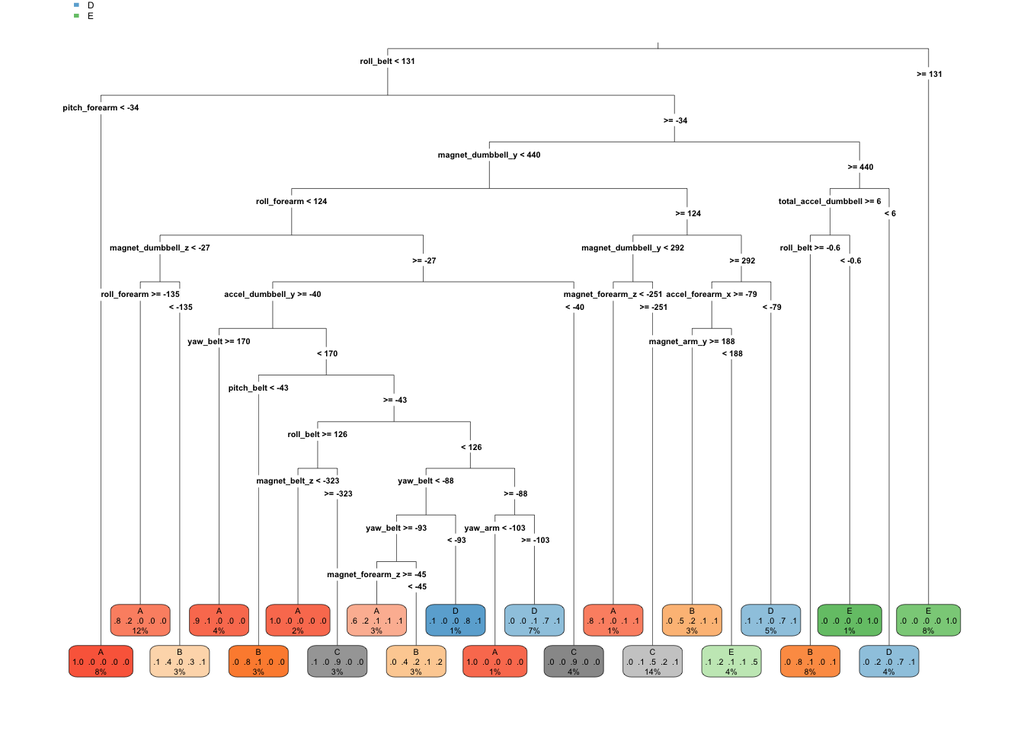

```r
library(rpart)
library(rpart.plot)
library(rattle)
trainD$classe <- as.factor(trainD$classe)
modtree <- rpart(classe~., data =trainD, method="class")
# Plot the prediction tree
rpart.plot(modtree, type=3, digits = 1, fallen.leaves = TRUE)
```

## Testing the model (modtree) on the validate data

```r
validate$classe <- as.factor(validate$classe)
pred_vali <- predict (modtree, newdata=validate, type="class")
confusionMatrix(validate$classe, pred_vali)
```

```
## Confusion Matrix and Statistics
##
##           Reference
## Prediction    A    B    C    D    E
##          A 1502   66   44   39   23
##          B  189  702  141   81   26
##          C   19  149  759   77   22
##          D   48   90  152  629   45
##          E   29  132  133  110  678
##
## Overall Statistics
##
##                Accuracy : 0.7256
##                  95% CI : (0.714, 0.7369)
##     No Information Rate : 0.3037
##     P-Value [Acc > NIR] : < 2.2e-16
##
##                   Kappa : 0.6521
##
##  Mcnemar's Test P-Value : < 2.2e-16
##
## Statistics by Class:
##
##                      Class: A Class: B Class: C Class: D Class: E
## Sensitivity            0.8405   0.6163   0.6176   0.6720   0.8539
## Specificity            0.9580   0.9079   0.9427   0.9323   0.9206
## Pos Pred Value         0.8973   0.6163   0.7398   0.6525   0.6266
## Neg Pred Value         0.9323   0.9079   0.9033   0.9376   0.9758
## Prevalence             0.3037   0.1935   0.2088   0.1590   0.1349
## Detection Rate         0.2552   0.1193   0.1290   0.1069   0.1152
## Detection Prevalence   0.2845   0.1935   0.1743   0.1638   0.1839
## Balanced Accuracy      0.8993   0.7621   0.7801   0.8022   0.8873
```

The decision tree predicts the validate set with 72.6% accuracy, giving an out of sample error of 0.274.

# Classification using random forest

## Model buiding and validation

The randomForest package runs the random forest modelling faster than the caret packege on its own. The random forest model (modrf) was used to predict the valiadate data set.

```r
library(randomForest)
set.seed(10000)
modrf <- randomForest(classe~., data=trainD, method="class")
pred_rf <- predict(modrf, newdata=validate)
confusionMatrix(validate$classe, pred_rf)
```

```
## Confusion Matrix and Statistics
##
##           Reference
## Prediction    A    B    C    D    E
##          A 1673    1    0    0    0
##          B    4 1131    4    0    0
##          C    0    5 1021    0    0
##          D    0    0    6  957    1
##          E    0    0    2    2 1078
##
## Overall Statistics
##
##                Accuracy : 0.9958
##                  95% CI : (0.9937, 0.9972)
##     No Information Rate : 0.285
##     P-Value [Acc > NIR] : < 2.2e-16
##
##                   Kappa : 0.9946
##
##  Mcnemar's Test P-Value : NA
##
## Statistics by Class:
##
##                      Class: A Class: B Class: C Class: D Class: E
## Sensitivity            0.9976   0.9947   0.9884   0.9979   0.9991
## Specificity            0.9998   0.9983   0.9990   0.9986   0.9992
## Pos Pred Value         0.9994   0.9930   0.9951   0.9927   0.9963
## Neg Pred Value         0.9991   0.9987   0.9975   0.9996   0.9998
## Prevalence             0.2850   0.1932   0.1755   0.1630   0.1833
## Detection Rate         0.2843   0.1922   0.1735   0.1626   0.1832
## Detection Prevalence   0.2845   0.1935   0.1743   0.1638   0.1839
## Balanced Accuracy      0.9987   0.9965   0.9937   0.9982   0.9991
```

## Prediction of 20 test sample

Due to its competitive accuracy of near 100% the random forest model was used to predict the 20 test samples as shown below.

```r
test20 <- predict(modrf, testing)
test20
```

```
##  1  2  3  4  5  6  7  8  9 10 11 12 13 14 15 16 17 18 19 20
##  B  A  B  A  A  E  D  B  A  A  B  C  B  A  E  E  A  B  B  B
## Levels: A B C D E
```

## Conclusion

The random forest model predicts the exercise class more accurately than the decision tree. This is because the random forest technique performs multiple iterations of the classification tree hence reduces the misclassification error.

## Reference

1. Ugulino, W.; Cardador, D.; Vega, K.; Velloso, E.; Milidiu, R.; Fuks, H. Wearable Computing: Accelerometers’ Data Classification of Body Postures and Movements. Proceedings of 21st Brazilian Symposium on Artificial Intelligence. Advances in Artificial Intelligence - SBIA 2012. In: Lecture Notes in Computer Science. , pp. 52-61. Curitiba, PR: Springer Berlin / Heidelberg, 2012. ISBN 978-3-642-34458-9. DOI: 10.1007/978-3-642-34459-6_6.

Read more: http://groupware.les.inf.puc-rio.br/har#ixzz6Kzt29mu4